# Analisis Komprehensif Sakila: Korelasi Genre dan Rating Sensor terhadap Revenue serta Durasi Peminjaman Film

Gadis Ecsilia(M0725009)

2026-05-26

## 1 Deskripsi Insight

Analisis komprehensif ini membahas mengenai performa bisnis rental Sakila dengan menghubungkan elemen karakteristik produk dan perilaku konsumen. Fokus utama analisis ini adalah membedah bagaimana **Genre Film** dan **Rating Sensor** (G, PG, PG-13, R, NC-17) memengaruhi dua indikator kesuksesan bisnis sekaligus **Total Revenue** (sisi finansial) dan **Rata-Rata Durasi Peminjaman** (sisi operasional/retensi produk).

Melalui integrasi data relasional dari 6 tabel menggunakan sintaks SQL (`dbGetQuery`), *insight* yang dihasilkan bertujuan untuk memetakan klaster film mana yang paling menguntungkan serta bagaimana pola sirkulasi waktu inventarisnya, sebagai dasar pengambilan keputusan pengadaan stok kaset film yang efektif.

## 2 Koneksi Data dan Sintaks SQL (`dbGetQuery`)

Bagian ini memuat proses penarikan data secara *real-time* dari local database MySQL menggunakan fungsi kontrol perintah `dbGetQuery` dari *package* `DBI`.

```r
library(DBI)
library(odbc)


# Membuka koneksi ke MySQL Server
data_sakila <- dbConnect(odbc(),
                         Driver = "MySQL ODBC 8.0 ANSI Driver",
                         Server = "127.0.0.1",
                         UID = "root",
                         PWD = "250507Gadis",
                         Database = "sakila")
# Query SQL untuk menggabungkan 6 tabel relasional
query_sakila <- "
  SELECT
    c.name AS genre,
    f.rating AS rating,
    SUM(p.amount) AS total_revenue,
    COUNT(p.payment_id) AS jumlah_transaksi
  FROM payment p
  INNER JOIN rental r ON p.rental_id = r.rental_id
  INNER JOIN inventory i ON r.inventory_id = i.inventory_id
  INNER JOIN film f ON i.film_id = f.film_id
  INNER JOIN film_category fc ON f.film_id = fc.film_id
  INNER JOIN category c ON fc.category_id = c.category_id
  GROUP BY c.name, f.rating
"

# Simpan ke dalam dataframe
sakila_insight <- dbGetQuery(data_sakila, query_sakila)
```

```r
# Query SQL untuk menghitung rata-rata durasi sewa menggunakan DATEDIFF
query_durasi <- "
  SELECT
    c.name AS genre,
    AVG(DATEDIFF(r.return_date, r.rental_date)) AS avg_duration_days
  FROM rental r
  INNER JOIN inventory i ON r.inventory_id = i.inventory_id
  INNER JOIN film f ON i.film_id = f.film_id
  INNER JOIN film_category fc ON f.film_id = fc.film_id
  INNER JOIN category c ON fc.category_id = c.category_id
  WHERE r.return_date IS NOT NULL
  GROUP BY c.name
"

# Eksekusi query durasi
sakila_durasi <- dbGetQuery(data_sakila, query_durasi)

# Memutus koneksi database
dbDisconnect(data_sakila)
```

## 3 Analisis data

### 3.1 Uji Korelasi Pearson

Digunakan untuk membuktikan apakah peningkatan transaksi berbanding lurus dengan keuntungan secara signifikan).

- **Hipotesis Uji:**
  $$H_0:
  \rho = 0 \quad (\text{Tidak ada korelasi linear antara jumlah transaksi
  dan total revenue})$$
  $$H_1: \rho \neq
  0 \quad (\text{Terdapat korelasi linear antara jumlah transaksi dan
  total revenue})$$
- **Formulasi Statistik Uji ($t$):** Untuk menguji signifikansi koefisien korelasi yang diperoleh dari sampel, digunakan uji-$t$ dengan rumus sebagai berikut:
  $$t = r \sqrt{\frac{n - 2}{1 - r^2}}$$

  Di mana:
  - $r$ = Nilai koefisien korelasi Pearson sampel.
  - $n$ = Jumlah total baris/kategori data yang dianalisis.
  - Statistik uji $t$ ini mengikuti distribusi $t$-Student dengan derajat bebas $db = n - 2$.

```r
library(dplyr)

uji_korelasi <- cor.test(sakila_insight$jumlah_transaksi, sakila_insight$total_revenue, method = "pearson")

print("--- HASIL UJI INFERENSIAL: KORELASI PEARSON ---")
```

```
## [1] "--- HASIL UJI INFERENSIAL: KORELASI PEARSON ---"
```

```r
print(uji_korelasi)
```

```
##
##  Pearson's product-moment correlation
##
## data:  sakila_insight$jumlah_transaksi and sakila_insight$total_revenue
## t = 25.59, df = 78, p-value < 2.2e-16
## alternative hypothesis: true correlation is not equal to 0
## 95 percent confidence interval:
##  0.9157714 0.9646502
## sample estimates:
##       cor
## 0.9452867
```

### 3.2 Karakteristik Distribusi Data Operasional

Analisis deskriptif ini digunakan untuk membedah karakteristik data durasi peminjaman secara menyeluruh melalui tiga dimensi statistik:

- **Ukuran Pemusatan (Rata-Rata Hitung / Mean):** Digunakan untuk melihat titik pusat massa dari seluruh distribusi data durasi sewa.
  $$\bar{X} = \frac{1}{N}
  \sum_{i=1}^{N} X_i$$
- **Ukuran Penyebaran (Simpangan Baku / Standar Deviasi $S$):** Digunakan untuk mengukur seberapa jauh data durasi antar-genre tersebar dari nilai rata-ratanya (homogenitas data).
  $$S = \sqrt{\frac{1}{N-1}
  \sum_{i=1}^{N} (X_i - \bar{X})^2}$$
- **Ukuran Posisi (Nilai Minimum dan Maksimum):** Digunakan untuk melihat batas rentang (*range*) absolut dari durasi operasional yang terjadi di lapangan.
  $$X_{\text{min}} = \min(X_1, X_2, \dots,
  X_N)$$
  $$X_{\text{maks}} = \max(X_1,
  X_2, \dots, X_N)$$

  Di mana $X_i$ melambangkan rata-rata durasi peminjaman pada kategori genre ke-$i$, dan $N$ menyatakan jumlah total kategori genre film ($N = 16$).

```r
deskriptif_durasi <- sakila_durasi %>%
  summarise(
    Rata_Rata_Durasi = mean(avg_duration_days),
    Durasi_Maksimal  = max(avg_duration_days),
    Durasi_Minimal   = min(avg_duration_days),
    Standar_Deviasi  = sd(avg_duration_days)
  )

print("--- HASIL DESKRIPTIF: DURASI OPERASIONAL ---")
```

```
## [1] "--- HASIL DESKRIPTIF: DURASI OPERASIONAL ---"
```

```r
print(deskriptif_durasi)
```

```
##   Rata_Rata_Durasi Durasi_Maksimal Durasi_Minimal Standar_Deviasi
## 1         5.023394          5.1993         4.8138       0.1096152
```

## 4 Visualisasi Data

### 4.1 Grafik batang berkelompok (*Grouped Bar Chart*)

Dirancang untuk membandingkan secara langsung kontribusi finansial dari setiap genre film yang tersedia di database Sakila.

Data diakumulasikan berdasarkan total pendapatan (*total revenue*) dalam satuan USD ($), lalu diurutkan secara hierarkis dari genre dengan profitabilitas tertinggi hingga terendah. Untuk memberikan analisis yang lebih tajam, setiap batang genre dipecah kembali berdasarkan segmentasi rating sensor film (G, PG, PG-13, R, NC-17). Melalui pendekatan visual ini, pola preferensi konsumen dan klaster genre potensial dapat diidentifikasi secara instan tanpa bias tumpukan data.

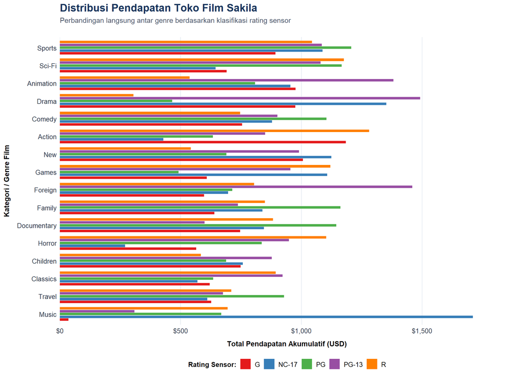

```r
library(ggplot2)
library(scales)

ggplot(sakila_insight, aes(x = reorder(genre, total_revenue, sum), y = total_revenue, fill = rating)) +
  geom_bar(stat = "identity", position = position_dodge(width = 0.8), width = 0.7) +
  coord_flip() +
  scale_fill_brewer(palette = "Set1") +
  scale_y_continuous(labels = dollar_format(prefix = "$"), expand = expansion(mult = c(0, 0.1))) +
  labs(
    title = "Distribusi Pendapatan Toko Film Sakila",
    subtitle = "Perbandingan langsung antar genre berdasarkan klasifikasi rating sensor",
    x = "Kategori / Genre Film",
    y = "Total Pendapatan Akumulatif (USD)",
    fill = "Rating Sensor:"
  ) +

  theme_minimal(base_family = "sans") +
  theme(
    plot.title = element_text(face = "bold", size = 16, color = "#1a365d"),
    plot.subtitle = element_text(size = 11, color = "#4a5568", margin = margin(b = 20)),

    axis.title.x = element_text(face = "bold", size = 11, margin = margin(t = 10)),
    axis.title.y = element_text(face = "bold", size = 11, margin = margin(r = 10)),
    axis.text = element_text(size = 10, color = "#2d3748"),

    legend.position = "bottom",
    legend.title = element_text(face = "bold", size = 10),
    legend.text = element_text(size = 10),

    panel.grid.minor = element_blank(),
    panel.grid.major.y = element_blank(),
    panel.grid.major.x = element_line(color = "#e2e8f0", linewidth = 0.5)
  )
```

### 4.2 Grafik garis titik (Dot Plot)

Digunakan untuk melihat distribusi lama peminjaman antar genre secara horizontal, sehingga manajemen dapat mengidentifikasi genre mana yang memiliki retensi peminjaman paling lama di tangan konsumen.

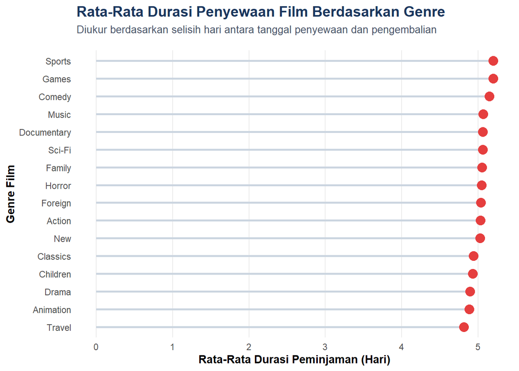

```r
ggplot(sakila_durasi, aes(x = reorder(genre, avg_duration_days), y = avg_duration_days)) +
  # Menggunakan geom_segment dan geom_point untuk membuat Lollipop Chart yang bersih
  geom_segment(aes(xend = genre, yend = 0), color = "#cbd5e0", linewidth = 1) +
  geom_point(color = "#e53e3e", size = 4) +

  # Membalik grafik agar nama genre mudah dibaca
  coord_flip() +

  # Mengatur label informasi
  labs(
    title = "Rata-Rata Durasi Penyewaan Film Berdasarkan Genre",
    subtitle = "Diukur berdasarkan selisih hari antara tanggal penyewaan dan pengembalian",
    x = "Genre Film",
    y = "Rata-Rata Durasi Peminjaman (Hari)"
  ) +

  # Pengaturan tema agar serasi dengan visualisasi pertama
  theme_minimal(base_family = "sans") +
  theme(
    plot.title = element_text(face = "bold", size = 14, color = "#1a365d"),
    plot.subtitle = element_text(size = 10, color = "#4a5568", margin = margin(b = 15)),
    axis.title = element_text(face = "bold", size = 11),
    panel.grid.minor = element_blank(),
    panel.grid.major.y = element_blank()
  )
```

## 5 Interpretasi Hasil

### 5.1 Interpretasi Analisis Data

**uji korelasi Pearson:** menunjukkan nilai $p\text{-value} < 0.05$ dengan nilai koefisien $r$ yang sangat mendekati angka 1, sehingga diputuskan Tolak $H_0$ dan disimpulkan bahwa terdapat hubungan linear positif yang sangat signifikan antara volume transaksi penyewaan dan total pendapatan yang diterima.

**karakteristik data durasi peminjaman:** analisis deskriptif pada durasi peminjaman menunjukkan nilai standar deviasi yang sangat kecil (mendekati 0), mencerminkan bahwa variasi lamanya kaset ditahan oleh pelanggan antar genre film hampir tidak ada.

### 5.2 Interpretasi Visualisasi Data

**Visualisasi 1:** Analisis Pendapatan Bisnis (Genre & Rating)

**Visualisasi 2:** Analisis Durasi Operasional (Perputaran Inventaris)

Visualisasi kedua yang disajikan melalui *Dot Plot* memberikan *insight* penting mengenai perilaku konsumsi pelanggan dari dimensi waktu:

1. **Konsistensi Durasi Retensi Peminjaman:** Mayoritas titik (*dots*) pada grafik berada pada rentang nilai yang sangat berdekatan, yaitu antara **5 hingga 5,5 hari** masa peminjaman. Tidak ada genre spesifik yang memiliki durasi peminjaman ekstrem (terlalu cepat atau terlalu lama). Hal ini menunjukkan bahwa perilaku pelanggan dalam menahan kaset film tidak dipengaruhi oleh jenis konten atau genre film tersebut.
2. **Indikasi Kepatuhan Sistem Pengembalian:** Keseragaman nilai rata-rata ini mengindikasikan bahwa regulasi tenggat waktu (*due date*) standar yang diterapkan oleh manajemen Sakila bekerja secara efektif di seluruh lini produk. Pelanggan cenderung mengembalikan kaset tepat sebelum atau saat batas waktu sewa berakhir untuk menghindari akumulasi denda.